Name: Ellen Mendy

Course: Natural Language Processing

Matr. -No.: 30006037

Topic: Sentiment analysis on customer reviews on American airlines

MOTIVATION This text analysis project was base on customers reviews on the six biggest USA airlines, the main aim of the project is to know the reviews about customer reaction to the airlines, this could help not just the airline regulartory body but also the airline company itself, but my reaserch will only concerntrate on all the airline reveiws put together.

ABOUT THE DATA A sentiment analysis job about the problems of each major U.S. airline. Twitter data was scraped from February of 2015 and contributors were asked to first classify positive, negative, and neutral tweets, followed by categorizing negative reasons (such as "late flight" or "rude service"). For example, it contains whether the sentiment of the tweets in this set was positive, neutral, or negative for six US airlines: The information of main attributes for this project as follows alirline_sentiment : Sentiment classification.(positivie, neutral, and negative) negativereason : Reason selected for the negative opinion

METHODLOGY *Loading the data

*EDA

*Preprocessing

*Machine learning Application

*Conclusion

```python
# This Python 3 environment comes with many helpful analytics libraries installed
# It is defined by the kaggle/python Docker image: https://github.com/kaggle/docker-python
# For example, here's several helpful packages to load

import numpy as np # linear algebra
import pandas as pd # data processing, CSV file I/O (e.g. pd.read_csv)

# Input data files are available in the read-only "../input/" directory
# For example, running this (by clicking run or pressing Shift+Enter) will list all files under the input directory

import os
for dirname, _, filenames in os.walk('/kaggle/input'):
    for filename in filenames:
        print(os.path.join(dirname, filename))

# You can write up to 20GB to the current directory (/kaggle/working/) that gets preserved as output when you create a version using "Save & Run All"
# You can also write temporary files to /kaggle/temp/, but they won't be saved outside of the current session
```

```python
# load dataset
df=pd.read_csv('Tweets.csv')
```

```python
df.head()
```

|  | tweet_id | airline_sentiment | airline_sentiment_confidence | negativereason | negativereason_confidence | airline | airline_sentiment_gold | name | negativereason_gold | retweet_count | text | tweet_coord | tweet_created | tweet_location | user_timezone |
| --- | --- | --- | --- | --- | --- | --- | --- | --- | --- | --- | --- | --- | --- | --- | --- |
| 0 | 570306133677760513 | neutral | 1.0000 | NaN | NaN | Virgin America | NaN | cairdin | NaN | 0 | @VirginAmerica What @dhepburn said. | NaN | 2015-02-24 11:35:52 -0800 | NaN | Eastern Time (US & Canada) |
| 1 | 570301130888122368 | positive | 0.3486 | NaN | 0.0000 | Virgin America | NaN | jnardino | NaN | 0 | @VirginAmerica plus you've added commercials t... | NaN | 2015-02-24 11:15:59 -0800 | NaN | Pacific Time (US & Canada) |
| 2 | 570301083672813571 | neutral | 0.6837 | NaN | NaN | Virgin America | NaN | yvonnalynn | NaN | 0 | @VirginAmerica I didn't today... Must mean I n... | NaN | 2015-02-24 11:15:48 -0800 | Lets Play | Central Time (US & Canada) |
| 3 | 570301031407624196 | negative | 1.0000 | Bad Flight | 0.7033 | Virgin America | NaN | jnardino | NaN | 0 | @VirginAmerica it's really aggressive to blast... | NaN | 2015-02-24 11:15:36 -0800 | NaN | Pacific Time (US & Canada) |
| 4 | 570300817074462722 | negative | 1.0000 | Can't Tell | 1.0000 | Virgin America | NaN | jnardino | NaN | 0 | @VirginAmerica and it's a really big bad thing... | NaN | 2015-02-24 11:14:45 -0800 | NaN | Pacific Time (US & Canada) |

# EDA

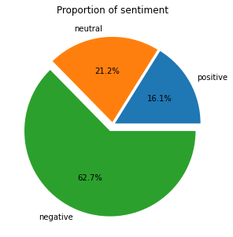

```python
x = df.airline_sentiment.value_counts().sort_values()

plt.figure(figsize=(5, 5))
ax = plt.pie(x = x, labels=x.index, autopct = '%1.1f%%', explode = [0.03, 0.03, 0.08])
plt.title('Proportion of sentiment')

plt.show()
```

Interpretation In the above picture graph we can already see that we have more of negative reviews, so therefore the twitter reviews on this particular data is a negative one, so this information will be vital to anyone who is interested to know

# Preprocessing

```python
#Checking the shape of the dataframe
df.shape
```

```
(14640, 15)
```

```python
#checking the data in index 0
df.text[0]
```

```
'@VirginAmerica What @dhepburn said.'
```

```python
#checking the colums in our data
df.columns
```

```
Index(['tweet_id', 'airline_sentiment', 'airline_sentiment_confidence',
       'negativereason', 'negativereason_confidence', 'airline',
       'airline_sentiment_gold', 'name', 'negativereason_gold',
       'retweet_count', 'text', 'tweet_coord', 'tweet_created',
       'tweet_location', 'user_timezone'],
      dtype='object')
```

```python
#taking variables that is relevant to our project
tweets=df[["text","airline_sentiment"]]
```

```python
tweets.head()
```

|  | text | airline_sentiment |
| --- | --- | --- |
| 0 | @VirginAmerica What @dhepburn said. | neutral |
| 1 | @VirginAmerica plus you've added commercials t... | positive |
| 2 | @VirginAmerica I didn't today... Must mean I n... | neutral |
| 3 | @VirginAmerica it's really aggressive to blast... | negative |
| 4 | @VirginAmerica and it's a really big bad thing... | negative |

```python
#data descriptive
tweets.text.str.len().describe()
```

```
count    14640.000000
mean       103.822063
std         36.277339
min         12.000000
25%         77.000000
50%        114.000000
75%        136.000000
max        186.000000
Name: text, dtype: float64
```

```python
#checking for missing values
tweets.isnull().sum()
```

```
text                 0
airline_sentiment    0
dtype: int64
```

```python
#checking the shape of the data
tweets.shape
```

```
(14640, 2)
```

```python
# Take sentiments as only binary Classifier leaving out the neutal as is not relevant
tweet_final=tweets[tweets["airline_sentiment"]!="neutral"]
```

```python
tweet_final
```

|  | text | airline_sentiment |
| --- | --- | --- |
| 1 | @VirginAmerica plus you've added commercials t... | positive |
| 3 | @VirginAmerica it's really aggressive to blast... | negative |
| 4 | @VirginAmerica and it's a really big bad thing... | negative |
| 5 | @VirginAmerica seriously would pay $30 a fligh... | negative |
| 6 | @VirginAmerica yes, nearly every time I fly VX... | positive |
| ... | ... | ... |
| 14633 | @AmericanAir my flight was Cancelled Flightled... | negative |
| 14634 | @AmericanAir right on cue with the delays👌 | negative |
| 14635 | @AmericanAir thank you we got on a different f... | positive |
| 14636 | @AmericanAir leaving over 20 minutes Late Flig... | negative |
| 14638 | @AmericanAir you have my money, you change my ... | negative |

11541 rows × 2 columns

```python
# Total number of tweets accoeding to sentiments
tweet_final["airline_sentiment"].value_counts()
```

```
negative    9178
positive    2363
Name: airline_sentiment, dtype: int64
```

```python
# Convert labels to integer value by factorize method
sentiment_label = tweet_final.airline_sentiment.factorize()
sentiment_label
```

```
(array([0, 1, 1, ..., 0, 1, 1], dtype=int64),
 Index(['positive', 'negative'], dtype='object'))
```

```python
tweet_data=tweet_final["text"].values
```

```python
#view the text data
tweet_data
```

```
array(["@VirginAmerica plus you've added commercials to the experience... tacky.",
       '@VirginAmerica it\'s really aggressive to blast obnoxious "entertainment" in your guests\' faces &amp; they have little recourse',
       "@VirginAmerica and it's a really big bad thing about it", ...,
       '@AmericanAir thank you we got on a different flight to Chicago.',
       "@AmericanAir leaving over 20 minutes Late Flight. No warnings or communication until we were 15 minutes Late Flight. That's called shitty customer svc",
       "@AmericanAir you have my money, you change my flight, and don't answer your phones! Any other suggestions so I can make my commitment??"],
      dtype=object)
```

```python
#install tensorflow package
pip install tensorflow
```

[output not shown]

```python
#loading libraries for preprocessing
import re
import nltk
from nltk.corpus import stopwords
nltk.download('stopwords')
from nltk.tokenize import word_tokenize
nltk.download('punkt')

def clean_stopword(d):
    stop_words = stopwords.words('english')
    for name in names:
        stop_words.append(name)

def tokenize(d):
    return word_tokenize(d)
```

```python
from nltk.corpus import stopwords
from nltk.tokenize import word_tokenize
# Add text
text = "How to remove stop words with NLTK library in Python"
print("Text:", text)
# Convert text to lowercase and split to a list of words
tokens = word_tokenize(text.lower())
print("Tokens:", tokens)
# Remove stop words
english_stopwords = stopwords.words('english')
tokens_wo_stopwords = [t for t in tokens if t not in english_stopwords]
print("Text without stop words:", " ".join(tokens_wo_stopwords))
```

```
Text: How to remove stop words with NLTK library in Python
Tokens: ['how', 'to', 'remove', 'stop', 'words', 'with', 'nltk', 'library', 'in', 'python']
Text without stop words: remove stop words nltk library python
```

```python
#tokens are created from sklearn library keras
from tensorflow.keras.preprocessing.text import Tokenizer
tokenizer = Tokenizer(num_words=5000)
tokenizer.fit_on_texts(tweet_data)
```

```python
# encoded data
encoded_data = tokenizer.texts_to_sequences(tweet_data)
```

```python
# vocab size is length of vocabaloury
vocab_size = len(tokenizer.word_index) + 1
```

```python
#tokening word index
tokenizer.word_index
```

[output not shown]

[output cut: 946 more lines]

[output not shown]